# S1 Análisis de factibilidad de construcción de nueva sede de UTEC

30 Agosto, 2023

```r
datos <- read_csv("DataLimpia.csv")
```

```
## -------------------------------------------------------- Delimiter: "," chr
## (7): Carrera, DProcedencia, Escala, CEconomica, TVivienda, DSede, DResi... dbl
## (11): ...1, Edad, Ciclo, CAVerdes, CADiscapacidad, CALugarCentrico, CAMa...
```

# Introducción

## Relevancia

La construcción de una nueva sede para la universidad es una solución para expandir su capacidad y permitir un crecimiento futuro. Además, puede ser una oportunidad para establecer objetivos en la construcción de espacios de aprendizaje innovadores y accesibles para todos. Una nueva sede moderna y atractiva también puede mejorar la visibilidad y reputación de la universidad, atrayendo a más estudiantes y profesores talentosos y consolidándose como una de las mejores opciones educativas en la región.

## Objetivos

1. Determinar entre los 3 distritos más votados donde se podría construir una nueva sede de la UTEC.
2. Identificar cuales serian los beneficios de la nueva sede y como afectaria a los alumnos.
3. Identificar las estructuras o areas que podría tener la nueva sede para los alumnos, para sus acividades diarias.

## Planificación

Según lo expresado, el proyecto fue diseñado teniendo en cuenta el plan de estudios y las instrucciones proporcionadas en clase. Esto sugiere que se siguió un enfoque estructurado y organizado para desarrollar el proyecto.

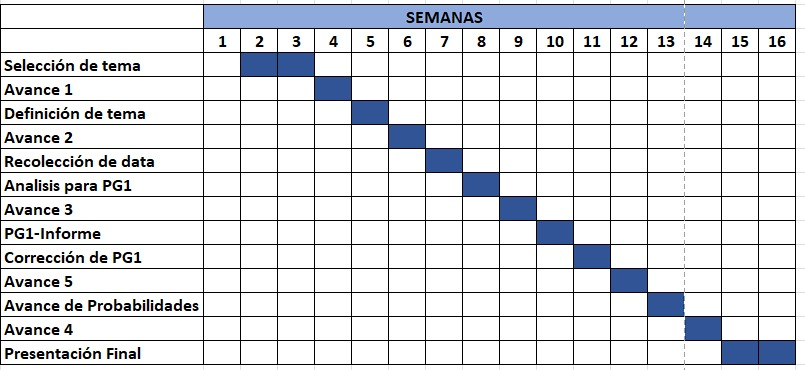

# Datos

## Población, muestra y muestreo

**Población:** La población objetivo de este estudio son todos los estudiantes de pregrado que se encuentran actualmente matriculados en el semestre 2023-1 en “UTEC”.

**Muestreo:** El muestreo es de tipo aleatorio simple.

## Variables

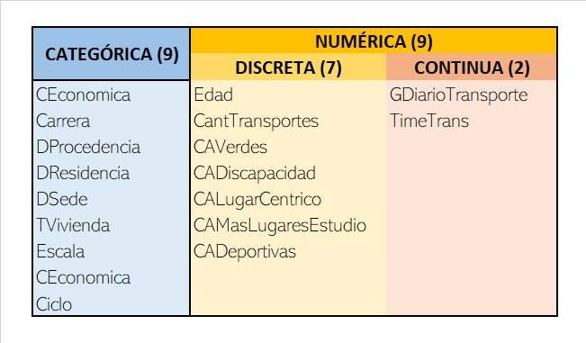